# Statistical Computing

School of Economics and Management  
Beihang University  
http://yanfei.site

## Motivation

## Discontinuous Functions

- The Newton Method requires first and second derivatives.
- If derivatives are not available the they can be approximated by Quasi-Newton methods.
- What if the derivatives do not exist?
- This may occur if there are discontinuities in the function.

## Business Example

- Suppose the aim is to optimize income of the business by selecting the number of workers.
- In the beginning adding more workers leads to more income for the business.
- If too many workers are employed, they may be less efficient and the income of the company goes down.

## Business Example

[figure not shown]

## Business Example

- Now suppose that there is a tax that the company must pay.
- Companies with less than 50 workers do not pay the tax.
- Companies with more than 50 workers do pay the tax.
- How does this change the problem?

## Business Example

[figure not shown]

## The Nelder Mead Algorithm

- The Nelder Mead algorithm is robust even when the functions are discontinuous.
- The idea is based on evaluating the function at the vertices of an n-dimensional simplex where n is the number of input variables into the function.
- For two dimensional problems the n-dimensional simplex is simply a triangle, and each corner is one vertex
- In general there are n + 1 vertices.

## A 2-dimensional simplex

[figure not shown]

## Step 1: Evaluate Function

- For each vertex \({\mathbf x_j}\) evaluate the function \(f({\mathbf x_j})\)
- Order the vertices so that \[f({\mathbf x_1})\leq f({\mathbf x_2})\leq\ldots\leq f({\mathbf x_{n+1}}).\]
- Suppose that the aim is to minimize the function, then \(f({\mathbf x_{n+1}})\) is the worst point.
- The aim is to replace \(f({\mathbf x_{n+1}})\) with a better point.

## A 2-dimensional simplex

[figure not shown]

## Step 2: Find Centroid

- After eliminating the worst point \({\mathbf x_{n+1}}\), compute the centroid of the remaining \(n\) points \[{\mathbf x_0}=\frac{1}{n}\sum_{j=1}^{n} {\mathbf x_j}.\]
- For the 2-dimensional example the centroid will be in the middle of a line.

## Find Centroid

[figure not shown]

## Step 3: Find reflected point

- Reflect the worst point around the centroid to get the reflected point.
- The formula is: \[{\mathbf x_r}={\mathbf x_0}+\alpha({\mathbf x_0}-{\mathbf x_{n+1}}).\]
- A common choice is \(\alpha=1\).
- In this case the reflected point is the same distance from the centroid as the worst point.

## Find Reflected Point

[figure not shown]

## Find Reflected Point

[figure not shown]

## Three cases

1. \(f({\mathbf x_1})\leq f({\mathbf x_r})<f({\mathbf x_n})\)
   - \({\mathbf x_r}\) is neither best nor worst point
2. \(f({\mathbf x_r})<f({\mathbf x_1})\)
   - \({\mathbf x_r}\) is the best point
3. \(f({\mathbf x_r})\geq f({\mathbf x_n})\)
   - \({\mathbf x_r}\) is the worst point

## Case 1

In Case 1 a new simplex is formed with \({\mathbf x_{n+1}}\) replaced by the reflected point \({\mathbf x_{r}}\). Then go back to step 1.

[figure not shown]

## Case 1

[figure not shown]

## Case 2

In Case 2, \({\mathbf x_r}<{\mathbf x_1}\). A good direction has been found so we expand along that direction \[ {\mathbf x_e}={\mathbf x_0}+\gamma({\mathbf x_r}-{\mathbf x_0}).\]

A common choice is \(\gamma=2\)

## Case 2

[figure not shown]

## Case 2

[figure not shown]

## Choosing the Expansion Point

- Evaluate \(f({\mathbf x_e})\).
- If \(f({\mathbf x_e}) < f({\mathbf x_r})\):
  - The expansion point is better than the reflection point. Form a new simplex with the expansion point
- If \(f({\mathbf x_r})\leq f({\mathbf x_e})\):
  - The expansion point is not better than the reflection point. Form a new simplex with the reflection point.

## Keep Expansion Point

[figure not shown]

## Keep Relection Point

[figure not shown]

## Case 3

Case 3 implies that there may be a valley between \({\mathbf x_{n+1}}\) and \({\mathbf x_{r}}\) so find the contracted point. A new simplex is formed with the contraction point if it is better than \({\mathbf x_{n+1}}\) \[{\mathbf x_c}={\mathbf x_0}+\rho({\mathbf x_{n+1}}-{\mathbf x_0})\]

A common choice is \(\rho=0.5\)

## Case 3

[figure not shown]

## Valley

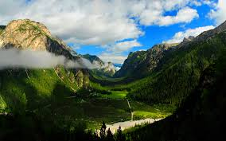

## Find Contraction point

[figure not shown]

## New Simplex

[figure not shown]

## Shrink

If \(f({\mathbf x_{n+1}})\leq f({\mathbf x_{c}})\) then contracting away from the worst point does not lead to a better point. In this case the function is too irregular a smaller simplex should be used. Shrink the simplex \[{\mathbf x_i}={\mathbf x_1}+\sigma({\mathbf x_i}-{\mathbf x_1})\]

A popular choice is \(\sigma=0.5\).

## Egg Carton

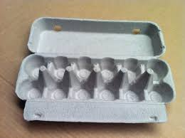

## Contraction Point is worst

[figure not shown]

## New Simplex

[figure not shown]

## Summary

- Order points
- Find centroid
- Find reflected point
- Three cases:
  1. Case 1 (\(f({\mathbf x_1})\leq f({\mathbf x_r})<f({\mathbf x_n})\)): Keep \({\mathbf x_r}\)
  2. Case 2 (\(f({\mathbf x_r}) < f({\mathbf x_1})\)): Find \(\mathbf x_e\).
     - If \(f({\mathbf x_e})<f({\mathbf x_r})\) then keep \(\mathbf x_e\)
     - Otherwise keep \(\mathbf x_r\)
  3. Case 3 (\(f({\mathbf x_r})\geq f({\mathbf x_n})\)): Find \(\mathbf x_c\)
     - If \(f({\mathbf x_c})<f({\mathbf x_{n+1}})\) then keep \(\mathbf x_c\)
     - Otherwise shrink

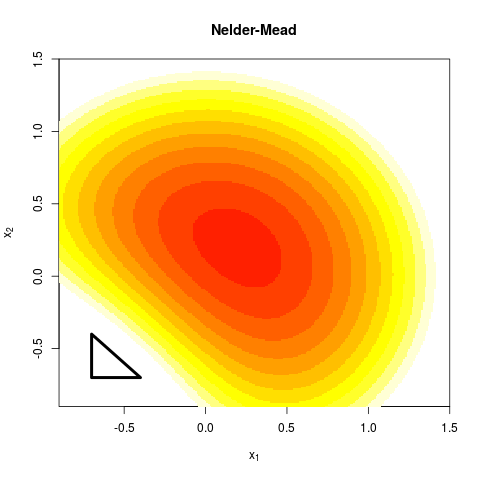

## Coding Nelder Mead

## Your task

- Find the minimum of the function \(f({\mathbf x})=x_1^2+x_2^2\)
- Use a triangle with vertices \((1,1)\), \((1,2)\), \((2,2)\) as the starting simplex
- Don't worry about using a loop just yet. Try to get code that just does the first iteration.
- Don't worry about the stopping rule yet either

## Use pseudo-code

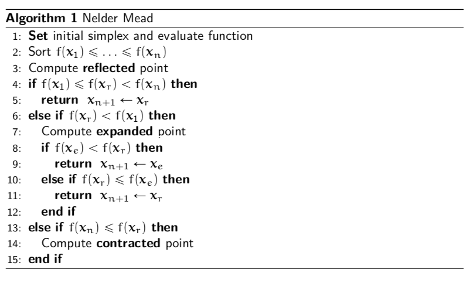

## Stopping Rule for Nelder Mead

- As Nelder Mead gets close to (or reaches) the minimum, the simplex gets smaller and smaller.
- One way to know that Nelder Mead has converged is by looking at the volume of the simplex.
- To work out the volume requires some understanding between the relationship between matrix algebra and geometry.

## Stopping Rule for Nelder Mead

- Choose the vertex \({\mathbf x_{n+1}}\) (although choosing any other vertex will also work)
- Build the matrix \(\tilde{X}=\left({\mathbf x_1}-{\mathbf x_{n+1}},{\mathbf x_2-{\mathbf x_{n+1}}},\ldots, {\mathbf x_{n}-{\mathbf x_{n+1}}}\right)\)
- The volume of the simplex is \(\frac{1}{2}|det(\tilde{X})|\)

## Why?

[figure not shown]

## Traslate

[figure not shown]

## Determinant=Area of Trapezoid

[figure not shown]

## Triangle=Half Trapezoid

[figure not shown]

## Alternative formula

Some of you may have learnt the formula for the area of a triangle as:\[\frac{1}{2}\left|det\left( \begin{array}{ccc} {\mathbf x_1}& {\mathbf x_2}& {\mathbf x_3}\\ 1 & 1 & 1 \end{array} \right)\right|\] The two approaches are equivalent.

## Nelder Mead in `optim()`

- Nelder Mead is the default algorithm in the R function `optim()`
- It is generally slower than Newton and Quasi-Newton methods but is more stable for functions that are not smooth.
- Including the argument `control=list(trace, REPORT=1)` will print out details about each step of the algorithm.
- Slight different terminology is used for example 'expansion' is called 'extension'

## Summary

- This is the end of the optimization topic.
- You should now be familiar with
  - Newton's Method
  - Quasi Newton Method
  - Nelder Mead
- Hopefully you also improved your coding skills!

## Summary

Some important lessons:

- If you can evaluate derivatives and Hessians then do so when implementing Newton and Quasi-Newton methods.
- If there are discontinuities in the function then Nelder Mead may work better.
- In any case the best strategy is to optimize using more than one method to check that results are robust.
- Also pay special attention to starting values. A good strategy is to check that results are robust to a few different choices of starting values.